# STAT408_HW4

2022-10-30

# Question 1

(15 points) Use the prostate data with lpsa as the response and the other variables as predictors. Implement the following variable selection methods to determine the “best” model:

```r
prostate <- read.csv("prostate.csv")
```

## part (a)

Backward elimination (0.05 cutoff)

```r
# Backward selection
# fit linear model with all predictors
prostate_model <- lm(lpsa ~ ., data = prostate)
summary(prostate_model)
```

```
##
## Call:
## lm(formula = lpsa ~ ., data = prostate)
##
## Residuals:
##     Min      1Q  Median      3Q     Max
## -1.7331 -0.3713 -0.0170  0.4141  1.6381
##
## Coefficients:
##              Estimate Std. Error t value Pr(>|t|)
## (Intercept)  0.669337   1.296387   0.516  0.60693
## lcavol       0.587022   0.087920   6.677 2.11e-09 ***
## lweight      0.454467   0.170012   2.673  0.00896 **
## age         -0.019637   0.011173  -1.758  0.08229 .
## lbph         0.107054   0.058449   1.832  0.07040 .
## svi          0.766157   0.244309   3.136  0.00233 **
## lcp         -0.105474   0.091013  -1.159  0.24964
## gleason      0.045142   0.157465   0.287  0.77503
## pgg45        0.004525   0.004421   1.024  0.30886
## ---
## Signif. codes:  0 '***' 0.001 '**' 0.01 '*' 0.05 '.' 0.1 ' ' 1
##
## Residual standard error: 0.7084 on 88 degrees of freedom
## Multiple R-squared:  0.6548, Adjusted R-squared:  0.6234
## F-statistic: 20.86 on 8 and 88 DF,  p-value: < 2.2e-16
```

```r
# fit linear model without gleason
prostate_model <- update(prostate_model, .~.-gleason)
summary(prostate_model)
```

```
##
## Call:
## lm(formula = lpsa ~ lcavol + lweight + age + lbph + svi + lcp +
##     pgg45, data = prostate)
##
## Residuals:
##      Min       1Q   Median       3Q      Max
## -1.73117 -0.38137 -0.01728  0.43364  1.63513
##
## Coefficients:
##              Estimate Std. Error t value Pr(>|t|)
## (Intercept)  0.953926   0.829439   1.150  0.25319
## lcavol       0.591615   0.086001   6.879 8.07e-10 ***
## lweight      0.448292   0.167771   2.672  0.00897 **
## age         -0.019336   0.011066  -1.747  0.08402 .
## lbph         0.107671   0.058108   1.853  0.06720 .
## svi          0.757734   0.241282   3.140  0.00229 **
## lcp         -0.104482   0.090478  -1.155  0.25127
## pgg45        0.005318   0.003433   1.549  0.12488
## ---
## Signif. codes:  0 '***' 0.001 '**' 0.01 '*' 0.05 '.' 0.1 ' ' 1
##
## Residual standard error: 0.7048 on 89 degrees of freedom
## Multiple R-squared:  0.6544, Adjusted R-squared:  0.6273
## F-statistic: 24.08 on 7 and 89 DF,  p-value: < 2.2e-16
```

```r
# fit linear model without lcp
prostate_model <- update(prostate_model, .~.-lcp)
summary(prostate_model)
```

```
##
## Call:
## lm(formula = lpsa ~ lcavol + lweight + age + lbph + svi + pgg45,
##     data = prostate)
##
## Residuals:
##      Min       1Q   Median       3Q      Max
## -1.77711 -0.41708  0.00002  0.40676  1.59681
##
## Coefficients:
##              Estimate Std. Error t value Pr(>|t|)
## (Intercept)  0.980085   0.830665   1.180  0.24116
## lcavol       0.545770   0.076431   7.141 2.31e-10 ***
## lweight      0.449450   0.168078   2.674  0.00890 **
## age         -0.017470   0.010967  -1.593  0.11469
## lbph         0.105755   0.058191   1.817  0.07249 .
## svi          0.641666   0.219757   2.920  0.00442 **
## pgg45        0.003528   0.003068   1.150  0.25331
## ---
## Signif. codes:  0 '***' 0.001 '**' 0.01 '*' 0.05 '.' 0.1 ' ' 1
##
## Residual standard error: 0.7061 on 90 degrees of freedom
## Multiple R-squared:  0.6493, Adjusted R-squared:  0.6259
## F-statistic: 27.77 on 6 and 90 DF,  p-value: < 2.2e-16
```

```r
# fit linear model without pgg45
prostate_model <- update(prostate_model, .~.-pgg45)
summary(prostate_model)
```

```
##
## Call:
## lm(formula = lpsa ~ lcavol + lweight + age + lbph + svi, data = prostate)
##
## Residuals:
##      Min       1Q   Median       3Q      Max
## -1.83505 -0.39396  0.00414  0.46336  1.57888
##
## Coefficients:
##             Estimate Std. Error t value Pr(>|t|)
## (Intercept)  0.95100    0.83175   1.143 0.255882
## lcavol       0.56561    0.07459   7.583 2.77e-11 ***
## lweight      0.42369    0.16687   2.539 0.012814 *
## age         -0.01489    0.01075  -1.385 0.169528
## lbph         0.11184    0.05805   1.927 0.057160 .
## svi          0.72095    0.20902   3.449 0.000854 ***
## ---
## Signif. codes:  0 '***' 0.001 '**' 0.01 '*' 0.05 '.' 0.1 ' ' 1
##
## Residual standard error: 0.7073 on 91 degrees of freedom
## Multiple R-squared:  0.6441, Adjusted R-squared:  0.6245
## F-statistic: 32.94 on 5 and 91 DF,  p-value: < 2.2e-16
```

```r
# fit linear model without age
prostate_model <- update(prostate_model, .~.-age)
summary(prostate_model)
```

```
##
## Call:
## lm(formula = lpsa ~ lcavol + lweight + lbph + svi, data = prostate)
##
## Residuals:
##      Min       1Q   Median       3Q      Max
## -1.82653 -0.42270  0.04362  0.47041  1.48530
##
## Coefficients:
##             Estimate Std. Error t value Pr(>|t|)
## (Intercept)  0.14554    0.59747   0.244  0.80809
## lcavol       0.54960    0.07406   7.422 5.64e-11 ***
## lweight      0.39088    0.16600   2.355  0.02067 *
## lbph         0.09009    0.05617   1.604  0.11213
## svi          0.71174    0.20996   3.390  0.00103 **
## ---
## Signif. codes:  0 '***' 0.001 '**' 0.01 '*' 0.05 '.' 0.1 ' ' 1
##
## Residual standard error: 0.7108 on 92 degrees of freedom
## Multiple R-squared:  0.6366, Adjusted R-squared:  0.6208
## F-statistic: 40.29 on 4 and 92 DF,  p-value: < 2.2e-16
```

```r
# fit linear model without lbph
prostate_model <- update(prostate_model, .~.-lbph)
summary(prostate_model)
```

```
##
## Call:
## lm(formula = lpsa ~ lcavol + lweight + svi, data = prostate)
##
## Residuals:
##      Min       1Q   Median       3Q      Max
## -1.72964 -0.45764  0.02812  0.46403  1.57013
##
## Coefficients:
##             Estimate Std. Error t value Pr(>|t|)
## (Intercept) -0.26809    0.54350  -0.493  0.62298
## lcavol       0.55164    0.07467   7.388  6.3e-11 ***
## lweight      0.50854    0.15017   3.386  0.00104 **
## svi          0.66616    0.20978   3.176  0.00203 **
## ---
## Signif. codes:  0 '***' 0.001 '**' 0.01 '*' 0.05 '.' 0.1 ' ' 1
##
## Residual standard error: 0.7168 on 93 degrees of freedom
## Multiple R-squared:  0.6264, Adjusted R-squared:  0.6144
## F-statistic: 51.99 on 3 and 93 DF,  p-value: < 2.2e-16
```

## part (b)

AIC

```r
# step AIC
prostate_model <- lm(lpsa ~ ., data = prostate)
step(prostate_model)
```

```
## Start:  AIC=-58.32
## lpsa ~ lcavol + lweight + age + lbph + svi + lcp + gleason +
##     pgg45
##
##           Df Sum of Sq    RSS     AIC
## - gleason  1    0.0412 44.204 -60.231
## - pgg45    1    0.5258 44.689 -59.174
## - lcp      1    0.6740 44.837 -58.853
## <none>                 44.163 -58.322
## - age      1    1.5503 45.713 -56.975
## - lbph     1    1.6835 45.847 -56.693
## - lweight  1    3.5861 47.749 -52.749
## - svi      1    4.9355 49.099 -50.046
## - lcavol   1   22.3721 66.535 -20.567
##
## Step:  AIC=-60.23
## lpsa ~ lcavol + lweight + age + lbph + svi + lcp + pgg45
##
##           Df Sum of Sq    RSS     AIC
## - lcp      1    0.6623 44.867 -60.789
## <none>                 44.204 -60.231
## - pgg45    1    1.1920 45.396 -59.650
## - age      1    1.5166 45.721 -58.959
## - lbph     1    1.7053 45.910 -58.560
## - lweight  1    3.5462 47.750 -54.746
## - svi      1    4.8984 49.103 -52.037
## - lcavol   1   23.5039 67.708 -20.872
##
## Step:  AIC=-60.79
## lpsa ~ lcavol + lweight + age + lbph + svi + pgg45
##
##           Df Sum of Sq    RSS     AIC
## - pgg45    1    0.6590 45.526 -61.374
## <none>                 44.867 -60.789
## - age      1    1.2649 46.131 -60.092
## - lbph     1    1.6465 46.513 -59.293
## - lweight  1    3.5647 48.431 -55.373
## - svi      1    4.2503 49.117 -54.009
## - lcavol   1   25.4189 70.285 -19.248
##
## Step:  AIC=-61.37
## lpsa ~ lcavol + lweight + age + lbph + svi
##
##           Df Sum of Sq    RSS     AIC
## <none>                 45.526 -61.374
## - age      1    0.9592 46.485 -61.352
## - lbph     1    1.8568 47.382 -59.497
## - lweight  1    3.2251 48.751 -56.735
## - svi      1    5.9517 51.477 -51.456
## - lcavol   1   28.7665 74.292 -15.871
```

```
##
## Call:
## lm(formula = lpsa ~ lcavol + lweight + age + lbph + svi, data = prostate)
##
## Coefficients:
## (Intercept)       lcavol      lweight          age         lbph          svi
##     0.95100      0.56561      0.42369     -0.01489      0.11184      0.72095
```

## part (c)

Do these model selection methods give you the same result? If not, do you think it is an issue that they are different? Give your insight.

According to backward elimination, the “best” model contains lcavol, lweight, and svi, while according to step AIC, the “best” model contains these three predictors in addition to age and lbph. It does not seem to be much of a problem that these two results differ slightly because they are still very similar with the exception of a couple predictors. This suggests that these predictors are right on the line of being significant or not and we should pay more careful attention to them when selecting the best model.

# Question 2

(15 points) The aatemp data come from the U.S. Historical Climatology Network. They are the annual mean temperatures (in degrees F) in Ann Arbor, Michigan going back about 150 years. Download this dataset from Sakai and answer following questions.

```r
aatemp <- read.csv("aatemp.csv")
```

## part (a)

Fit a linear model of temp~year. Do you think there is a linear trend? (Hint: check plot, parameters, and model goodness of fit)

```r
temp_model <- lm(temp ~ year, data = aatemp)
summary(temp_model)
```

```
##
## Call:
## lm(formula = temp ~ year, data = aatemp)
##
## Residuals:
##     Min      1Q  Median      3Q     Max
## -3.9843 -0.9113 -0.0820  0.9946  3.5343
##
## Coefficients:
##              Estimate Std. Error t value Pr(>|t|)
## (Intercept) 24.005510   7.310781   3.284  0.00136 **
## year         0.012237   0.003768   3.247  0.00153 **
## ---
## Signif. codes:  0 '***' 0.001 '**' 0.01 '*' 0.05 '.' 0.1 ' ' 1
##
## Residual standard error: 1.466 on 113 degrees of freedom
## Multiple R-squared:  0.08536,    Adjusted R-squared:  0.07727
## F-statistic: 10.55 on 1 and 113 DF,  p-value: 0.001533
```

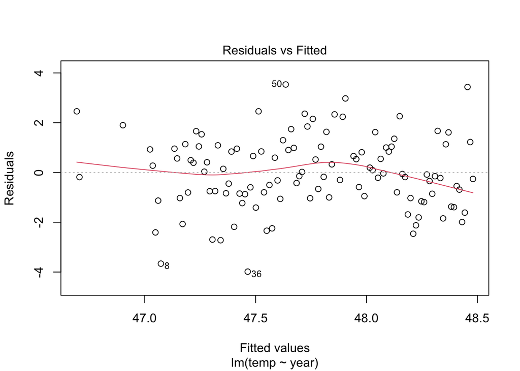

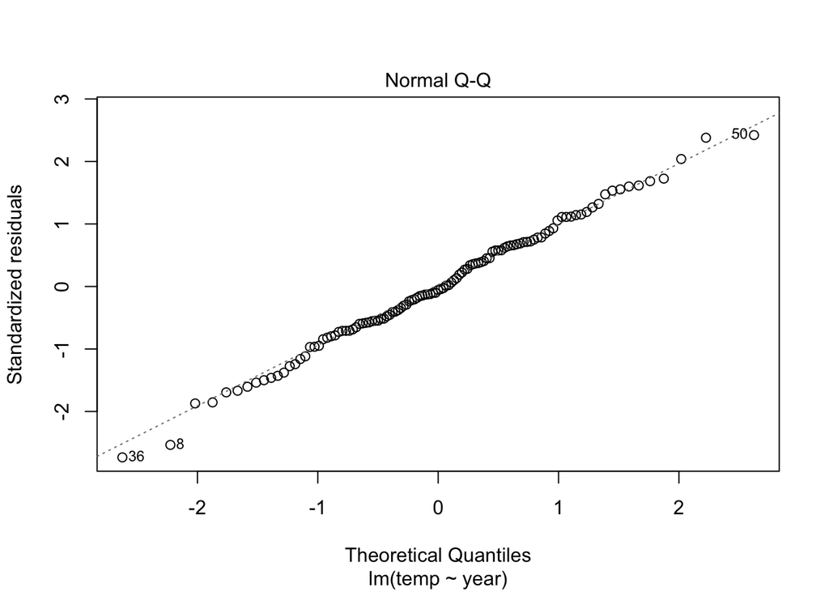

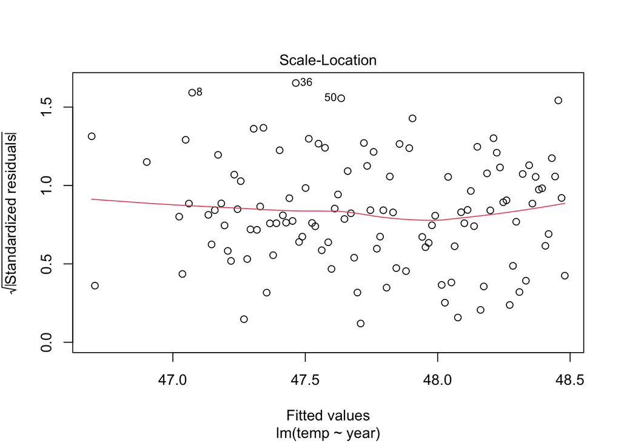

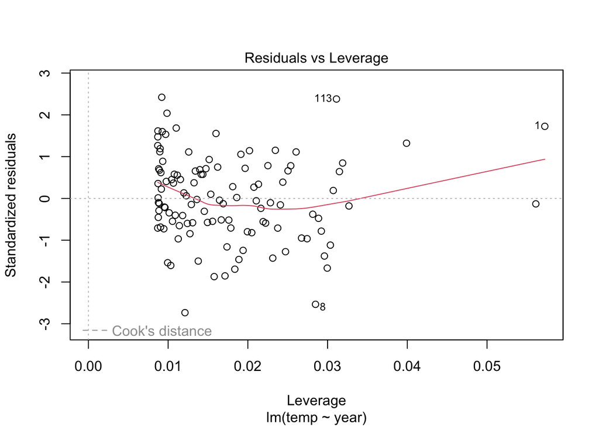

```r
plot(temp_model)
```

## part (b)

Observations in successive years may be correlated. Fit a model that estimates this correlation. Does this change your opinion about the trend?

```r
lm.year <- lm(temp ~ I(year-1), data = aatemp)
summary(lm.year)
```

```
##
## Call:
## lm(formula = temp ~ I(year - 1), data = aatemp)
##
## Residuals:
##     Min      1Q  Median      3Q     Max
## -3.9843 -0.9113 -0.0820  0.9946  3.5343
##
## Coefficients:
##              Estimate Std. Error t value Pr(>|t|)
## (Intercept) 24.017748   7.307013   3.287  0.00135 **
## I(year - 1)  0.012237   0.003768   3.247  0.00153 **
## ---
## Signif. codes:  0 '***' 0.001 '**' 0.01 '*' 0.05 '.' 0.1 ' ' 1
##
## Residual standard error: 1.466 on 113 degrees of freedom
## Multiple R-squared:  0.08536,    Adjusted R-squared:  0.07727
## F-statistic: 10.55 on 1 and 113 DF,  p-value: 0.001533
```

```r
cor(aatemp$year, I(aatemp$year-1))
```

```
## [1] 1
```

## part (c)

Fit a polynomial model with degree 5. Plot your fitted model on top of the data.

```r
temp_model3 <- lm(temp ~ year + I(year^2) + I(year^3) + I(year^4) + I(year^5), data = aatemp)
temp_model3 <- lm(temp ~ poly(year, 5, raw = TRUE), data = aatemp)
summary(temp_model3)
```

```
##
## Call:
## lm(formula = temp ~ poly(year, 5, raw = TRUE), data = aatemp)
##
## Residuals:
##     Min      1Q  Median      3Q     Max
## -4.0085 -0.9618 -0.0913  0.9926  3.7370
##
## Coefficients: (1 not defined because of singularities)
##                              Estimate Std. Error t value Pr(>|t|)
## (Intercept)                 1.497e+06  8.553e+05   1.750   0.0829 .
## poly(year, 5, raw = TRUE)1 -3.086e+03  1.775e+03  -1.739   0.0849 .
## poly(year, 5, raw = TRUE)2  2.385e+00  1.381e+00   1.727   0.0869 .
## poly(year, 5, raw = TRUE)3 -8.189e-04  4.773e-04  -1.716   0.0890 .
## poly(year, 5, raw = TRUE)4  1.054e-07  6.186e-08   1.704   0.0912 .
## poly(year, 5, raw = TRUE)5         NA         NA      NA       NA
## ---
## Signif. codes:  0 '***' 0.001 '**' 0.01 '*' 0.05 '.' 0.1 ' ' 1
##
## Residual standard error: 1.431 on 110 degrees of freedom
## Multiple R-squared:  0.1522, Adjusted R-squared:  0.1213
## F-statistic: 4.936 on 4 and 110 DF,  p-value: 0.001068
```

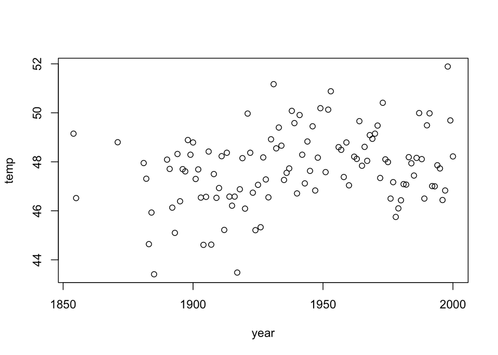

```r
plot(temp ~ year, data = aatemp)
abline(lm(temp ~ poly(year, 5, raw = TRUE), data = aatemp))
```

## part (d)

Suppose someone claims that the temperature trend was different before and after 1930. Fit a segmented regression model to check this claim.

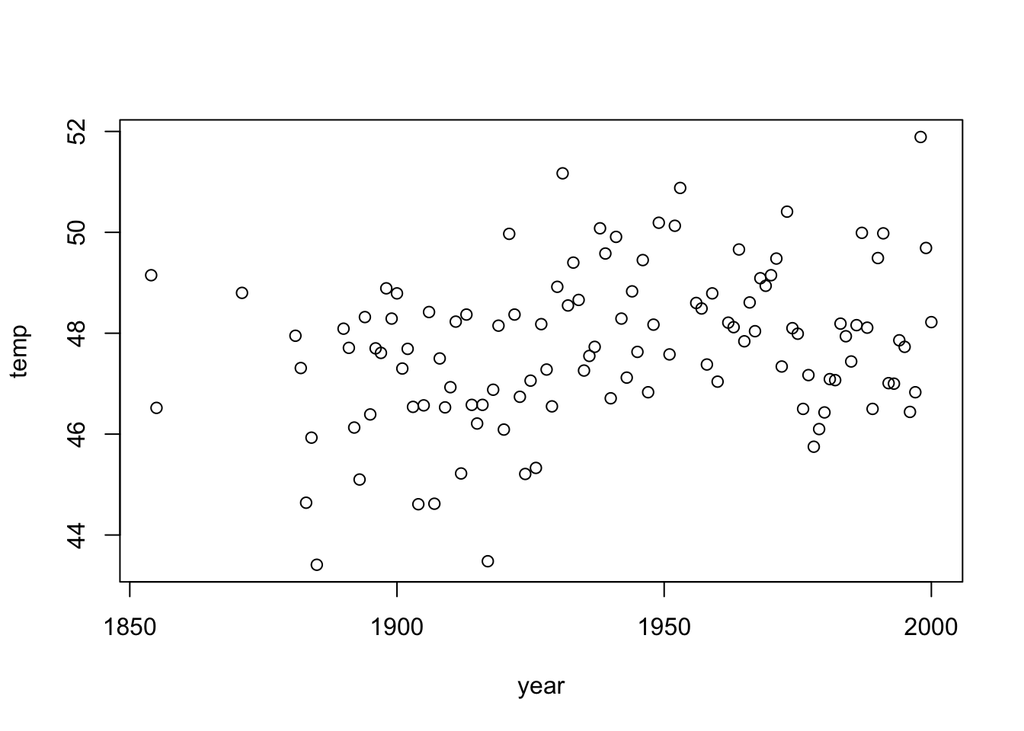

```r
# two base functions
bl <- function(x){
  ifelse(x<1930, 1930-x, 0)
}

br <- function(x){
  ifelse(x>1930, x-1930, 0)
}

# fit a segmented model
lm.seg <- lm(temp ~ bl(year) + br(year), data = aatemp)

# plot model
x <- seq(20, 48, by=1)
y <- lm.seg$coefficients[1]+lm.seg$coefficients[2]*bl(x)+lm.seg$coefficients[3]*br(x)
plot(temp ~ year, data = aatemp, xlab='year', ylab='temp')
lines(x,y,lty=2)
```

```r
summary(lm.seg)
```

```
##
## Call:
## lm(formula = temp ~ bl(year) + br(year), data = aatemp)
##
## Residuals:
##     Min      1Q  Median      3Q     Max
## -4.0855 -0.9492 -0.0380  1.0289  3.6096
##
## Coefficients:
##              Estimate Std. Error t value Pr(>|t|)
## (Intercept) 47.836412   0.259571  184.29   <2e-16 ***
## bl(year)    -0.020838   0.009559   -2.18   0.0314 *
## br(year)     0.006529   0.006942    0.94   0.3490
## ---
## Signif. codes:  0 '***' 0.001 '**' 0.01 '*' 0.05 '.' 0.1 ' ' 1
##
## Residual standard error: 1.467 on 112 degrees of freedom
## Multiple R-squared:  0.09312,    Adjusted R-squared:  0.07693
## F-statistic:  5.75 on 2 and 112 DF,  p-value: 0.004195
```

# Question 3

(15 points) The “longley” dataset includes the following seven social-economic variables from 1947-1962 in the US:

GNP.deflator: GNP implicit price deflator (1954=100) GNP: Gross National Product. Unemployed: number of unemployed. Armed.Forces: number of people in the armed forces. Population: population ≥ 14 years of age. Year: the year (time). Employed: number of people employed.

Our goal is to explore the relationship between Employed and other variables. Download this dataset from Sakai and answer the following questions.

```r
longley <- read.csv("longley.csv")
employed <- lm(Employed ~ ., data = longley)
summary(employed)
```

```
##
## Call:
## lm(formula = Employed ~ ., data = longley)
##
## Residuals:
##      Min       1Q   Median       3Q      Max
## -0.41011 -0.15767 -0.02816  0.10155  0.45539
##
## Coefficients:
##                Estimate Std. Error t value Pr(>|t|)
## (Intercept)  -3.482e+03  8.904e+02  -3.911 0.003560 **
## GNP.deflator  1.506e-02  8.492e-02   0.177 0.863141
## GNP          -3.582e-02  3.349e-02  -1.070 0.312681
## Unemployed   -2.020e-02  4.884e-03  -4.136 0.002535 **
## Armed.Forces -1.033e-02  2.143e-03  -4.822 0.000944 ***
## Population   -5.110e-02  2.261e-01  -0.226 0.826212
## Year          1.829e+00  4.555e-01   4.016 0.003037 **
## ---
## Signif. codes:  0 '***' 0.001 '**' 0.01 '*' 0.05 '.' 0.1 ' ' 1
##
## Residual standard error: 0.3049 on 9 degrees of freedom
## Multiple R-squared:  0.9955, Adjusted R-squared:  0.9925
## F-statistic: 330.3 on 6 and 9 DF,  p-value: 4.984e-10
```

## part (a)

Construct a correlation matrix of six predictors in this dataset. Which predictors do you think are highly correlated? What are the potential reasons for those high correlations?

```r
cor(longley)
```

```
##              GNP.deflator       GNP Unemployed Armed.Forces Population
## GNP.deflator    1.0000000 0.9915892  0.6206334    0.4647442  0.9791634
## GNP             0.9915892 1.0000000  0.6042609    0.4464368  0.9910901
## Unemployed      0.6206334 0.6042609  1.0000000   -0.1774206  0.6865515
## Armed.Forces    0.4647442 0.4464368 -0.1774206    1.0000000  0.3644163
## Population      0.9791634 0.9910901  0.6865515    0.3644163  1.0000000
## Year            0.9911492 0.9952735  0.6682566    0.4172451  0.9939528
## Employed        0.9708985 0.9835516  0.5024981    0.4573074  0.9603906
##                   Year  Employed
## GNP.deflator 0.9911492 0.9708985
## GNP          0.9952735 0.9835516
## Unemployed   0.6682566 0.5024981
## Armed.Forces 0.4172451 0.4573074
## Population   0.9939528 0.9603906
## Year         1.0000000 0.9713295
## Employed     0.9713295 1.0000000
```

GNP.deflator, GNP, population, year, and employed are highly correlated with one another as they have correlation coefficients of above 0.9. This is probably because the population affects the market, which is measured by things like GNP, and the number of people employed as well as year would also have a large effect on things like that because it affects the market for goods and services, how things are priced, and how people are doing financially.

## part (b)

Regress each predictor on others to examine the collinearity. Do you have same conclusion as in (a)?

```r
# regression among predictors
X <- model.matrix(employed)[,-1]
for(i in 1:6){
  r2 <- summary(lm(X[,i]~X[,-i]))$r.squared
  cat(colnames(X)[i], '\t', r2, '\n')
}
```

```
## GNP.deflator      0.9926217
## GNP   0.9994409
## Unemployed    0.9702548
## Armed.Forces      0.7213654
## Population    0.9974947
## Year      0.9986824
```

Yes, the variables GNP.deflator, GNP, Unemployed, Population, and Year all have very high $R^2$ values that are all greater than 0.9 and very close to one, suggesting that there is collinearity among these predictors. The only predictor that was included in this result but not in part b was Unemployed.

## part (c)

Try to remove some highly correlated predictors. Compare the full model and the smaller model. Do you think the smaller model is better? Give you reason.

```r
employed_new <- lm(Employed ~ Armed.Forces + Unemployed + Year, data = longley)
summary(employed_new)
```

```
##
## Call:
## lm(formula = Employed ~ Armed.Forces + Unemployed + Year, data = longley)
##
## Residuals:
##      Min       1Q   Median       3Q      Max
## -0.57285 -0.11989  0.04087  0.13979  0.75303
##
## Coefficients:
##                Estimate Std. Error t value Pr(>|t|)
## (Intercept)  -1.797e+03  6.864e+01 -26.183 5.89e-12 ***
## Armed.Forces -7.723e-03  1.837e-03  -4.204  0.00122 **
## Unemployed   -1.470e-02  1.671e-03  -8.793 1.41e-06 ***
## Year          9.564e-01  3.553e-02  26.921 4.24e-12 ***
## ---
## Signif. codes:  0 '***' 0.001 '**' 0.01 '*' 0.05 '.' 0.1 ' ' 1
##
## Residual standard error: 0.3321 on 12 degrees of freedom
## Multiple R-squared:  0.9928, Adjusted R-squared:  0.9911
## F-statistic: 555.2 on 3 and 12 DF,  p-value: 3.916e-13
```

```r
# regression among predictors
X <- model.matrix(employed_new)[,-1]
for(i in 1:3){
  r2 <- summary(lm(X[,i]~X[,-i]))$r.squared
  cat(colnames(X)[i], '\t', r2, '\n')
}
```

```
## Armed.Forces      0.5502216
## Unemployed    0.6986072
## Year      0.7429875
```

Yes, this new, smaller model appears to be better than the original full model because it still has a very high adjusted $R^2$ value of 0.9911, although this is just slightly less than the original value of 0.9925. However, this model only includes the predictors that were significant at a level of $alpha$ = 0.05 in the original model and the model passes the check of collinearity by regressing the predictors on the others as all of the $R^2$ values are not super close to one.

# Question 4

(15 points) The gala dataset contains 30 Galapagos islands and 7 variables. The relationship between the number of plant species and several geographic variables is of interest.

The dataset galamiss contains the Galapagos data with missing values left in. Use two datasets to answer following questions.

```r
gala <- read.csv("gala.csv")
galamiss <- read.csv("galamiss.csv")
```

## part (a)

Fit a linear model using gala (the data without missing) with the number of species as the response and the five geographic predictors (without Endemics).

```r
gala_model <- lm(Species ~ Area + Elevation + Nearest + Scruz + Adjacent, data = gala)
summary(gala_model)
```

```
##
## Call:
## lm(formula = Species ~ Area + Elevation + Nearest + Scruz + Adjacent,
##     data = gala)
##
## Residuals:
##      Min       1Q   Median       3Q      Max
## -111.679  -34.898   -7.862   33.460  182.584
##
## Coefficients:
##              Estimate Std. Error t value Pr(>|t|)
## (Intercept)  7.068221  19.154198   0.369 0.715351
## Area        -0.023938   0.022422  -1.068 0.296318
## Elevation    0.319465   0.053663   5.953 3.82e-06 ***
## Nearest      0.009144   1.054136   0.009 0.993151
## Scruz       -0.240524   0.215402  -1.117 0.275208
## Adjacent    -0.074805   0.017700  -4.226 0.000297 ***
## ---
## Signif. codes:  0 '***' 0.001 '**' 0.01 '*' 0.05 '.' 0.1 ' ' 1
##
## Residual standard error: 60.98 on 24 degrees of freedom
## Multiple R-squared:  0.7658, Adjusted R-squared:  0.7171
## F-statistic:  15.7 on 5 and 24 DF,  p-value: 6.838e-07
```

## part (b)

In galamiss, which variable(s) includes missing value? How many missing values do we have?

```r
colSums(is.na(galamiss))
```

```
##   Species  Endemics      Area Elevation   Nearest     Scruz  Adjacent
##         0         0         0         6         0         0         0
```

Elevation includes 6 missing values while none of the other variables have missing values.

## part (c)

Fit the same linear model to galamiss using the deletion strategy for missing values. Compare the fit to that in (a).

```r
gala_nomiss <- na.omit(galamiss)
deletion_model <- lm(Species ~ Area + Elevation + Nearest + Scruz + Adjacent, data = gala_nomiss)
summary(deletion_model)
```

```
##
## Call:
## lm(formula = Species ~ Area + Elevation + Nearest + Scruz + Adjacent,
##     data = gala_nomiss)
##
## Residuals:
##     Min      1Q  Median      3Q     Max
## -115.17  -37.60  -10.08   35.17  172.54
##
## Coefficients:
##             Estimate Std. Error t value Pr(>|t|)
## (Intercept) 15.32286   27.47417   0.558  0.58391
## Area        -0.02765    0.02557  -1.081  0.29388
## Elevation    0.32550    0.06476   5.026 8.78e-05 ***
## Nearest     -0.11042    1.17784  -0.094  0.92635
## Scruz       -0.28427    0.25422  -1.118  0.27818
## Adjacent    -0.07880    0.02092  -3.766  0.00141 **
## ---
## Signif. codes:  0 '***' 0.001 '**' 0.01 '*' 0.05 '.' 0.1 ' ' 1
##
## Residual standard error: 67.36 on 18 degrees of freedom
## Multiple R-squared:  0.7668, Adjusted R-squared:  0.702
## F-statistic: 11.83 on 5 and 18 DF,  p-value: 3.54e-05
```

This model is very similar to the one found in part a as both elevation and Adjacent are still the only two significant predictors at the level $alpha$ = 0.01. Additionally, the adjusted $R^2$ value is pretty similar to that found in part a, although it is just slightly less than the original value of 0.7171.

## part (d)

Use mean value imputation on galamiss and again fit the model. Compare to previous fits.

```r
means <- colMeans(galamiss, na.rm = T)
galamiss.impute <- galamiss
for(i in 1:6){
  galamiss.impute[is.na(galamiss.impute[,i]), i] <- means[i]
}
summary(lm(Species~Area + Elevation + Nearest + Scruz + Adjacent, data = galamiss.impute))
```

```
##
## Call:
## lm(formula = Species ~ Area + Elevation + Nearest + Scruz + Adjacent,
##     data = galamiss.impute)
##
## Residuals:
##     Min      1Q  Median      3Q     Max
## -94.710 -42.598  -9.742  26.146 220.893
##
## Coefficients:
##              Estimate Std. Error t value Pr(>|t|)
## (Intercept) -12.48266   28.62644  -0.436 0.666695
## Area         -0.00137    0.02683  -0.051 0.959697
## Elevation     0.27388    0.06891   3.975 0.000562 ***
## Nearest       0.37776    1.28270   0.295 0.770905
## Scruz        -0.08544    0.27140  -0.315 0.755629
## Adjacent     -0.06553    0.02215  -2.958 0.006856 **
## ---
## Signif. codes:  0 '***' 0.001 '**' 0.01 '*' 0.05 '.' 0.1 ' ' 1
##
## Residual standard error: 74.52 on 24 degrees of freedom
## Multiple R-squared:  0.6503, Adjusted R-squared:  0.5774
## F-statistic: 8.925 on 5 and 24 DF,  p-value: 6.77e-05
```

THis model appears to be worse than the previous two fits. Although the same predictors, Elevation and Adjacent, still appear to be very significant, the adjusted $R^2$ value of 0.5774 is less than the previous two values of around 0.7. Therefore, this model as not as good of a fit for predicting Species as the previous models.

## part (e)

Use a regression-based imputation based on the other four geographic predictors to fill in the missing values in galamiss. Fit the same model and compare to previous fits.

```r
# impute elevation
lm.impute <- lm(Elevation ~ Area + Nearest + Scruz + Adjacent, data = galamiss)
Elevation.impute <- predict(lm.impute, galamiss[is.na(galamiss$Elevation),])
round(Elevation.impute, 2)
```

```
##      1      5      6      9     21     28
## 270.26 466.59 289.35 265.13 267.06 260.89
```

```r
galamiss.impute1 <- galamiss
galamiss.impute1[is.na(galamiss.impute1$Elevation),] <- Elevation.impute

summary(lm(Species~Area + Elevation + Nearest + Scruz + Adjacent, data = galamiss.impute1))
```

```
##
## Call:
## lm(formula = Species ~ Area + Elevation + Nearest + Scruz + Adjacent,
##     data = galamiss.impute1)
##
## Residuals:
##      Min       1Q   Median       3Q      Max
## -122.376  -33.096   -1.496   14.058  183.169
##
## Coefficients:
##             Estimate Std. Error t value Pr(>|t|)
## (Intercept) 12.33709   23.84477   0.517 0.609619
## Area        -0.02119    0.02211  -0.958 0.347532
## Elevation    0.30902    0.05546   5.572 9.85e-06 ***
## Nearest      1.14590    0.18952   6.046 3.04e-06 ***
## Scruz       -0.40790    0.20023  -2.037 0.052804 .
## Adjacent    -0.07235    0.01783  -4.058 0.000455 ***
## ---
## Signif. codes:  0 '***' 0.001 '**' 0.01 '*' 0.05 '.' 0.1 ' ' 1
##
## Residual standard error: 60.24 on 24 degrees of freedom
## Multiple R-squared:  0.8498, Adjusted R-squared:  0.8185
## F-statistic: 27.15 on 5 and 24 DF,  p-value: 3.826e-09
```

This model appears to be the best of all of the models in this question. Not only does it have some additional significant predictors, Nearest and Scruz, at the level $alpha$ = 0.1, but it also has the largest adjusted $R^2$ value of 0.8185, suggesting that it is a pretty good fit for estimating Species.